# Reproducible Research: Peer Assessment 1

Daniel Baquero

5/7/2020

## Loading libraries

```r
library(dplyr)
```

```r
library(ggplot2)
```

## Loading and preprocessing the data

First we must load the data and process it for future work.

```r
dat <- read.csv("./activity.csv")
dat <- mutate(dat, date = as.Date(date))
str(dat)
```

```
## 'data.frame':    17568 obs. of  3 variables:
##  $ steps   : int  NA NA NA NA NA NA NA NA NA NA ...
##  $ date    : Date, format: "2012-10-01" "2012-10-01" ...
##  $ interval: int  0 5 10 15 20 25 30 35 40 45 ...
```

```r
summary(dat)
```

```
##      steps             date               interval
##  Min.   :  0.00   Min.   :2012-10-01   Min.   :   0.0
##  1st Qu.:  0.00   1st Qu.:2012-10-16   1st Qu.: 588.8
##  Median :  0.00   Median :2012-10-31   Median :1177.5
##  Mean   : 37.38   Mean   :2012-10-31   Mean   :1177.5
##  3rd Qu.: 12.00   3rd Qu.:2012-11-15   3rd Qu.:1766.2
##  Max.   :806.00   Max.   :2012-11-30   Max.   :2355.0
##  NA's   :2304
```

As we can see, now, we have a data frame with the number of steps, the date, and the interval.  
It looks like there are a bunch (2304) of NA’s in the steps variable.

## What is mean total number of steps taken per day?

To do this we first group the data by the date varibale. Then we summarize it by adding the total steps per day and asign the result to a new data frame called total_day.

```r
total_day <- group_by(dat, date) %>% summarize(total_steps = sum(steps))
```

Lets plot the histogram for the total number of steps per day.

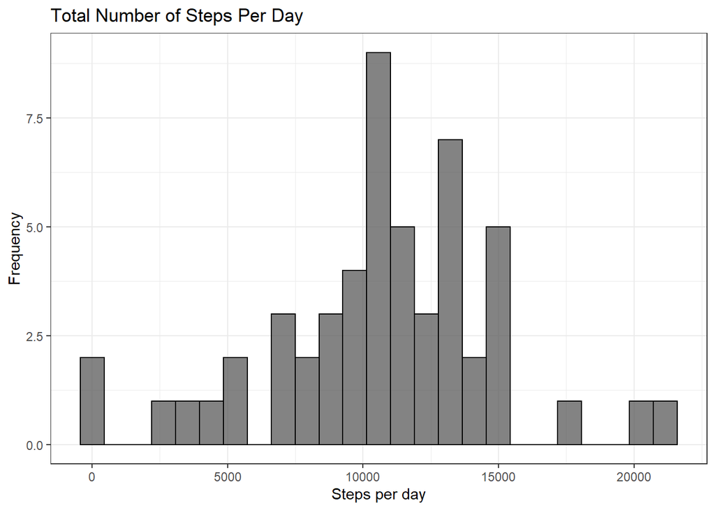

```r
{ggplot(total_day, aes(total_steps)) +
        geom_histogram(bins = 25, alpha = 0.75, color = "black") +
        labs(title = "Total Number of Steps Per Day",
             x = "Steps per day",
             y = "Frequency") +
        theme_bw()}
```

We can calculate the mean and median of the total number of steps per day.

```r
summary(total_day$total_steps)
```

```
##    Min. 1st Qu.  Median    Mean 3rd Qu.    Max.    NA's
##      41    8841   10765   10766   13294   21194       8
```

As shown above, the mean number of total steps per day is 10766 and the median are 10765. Those numbers are pretty close.

## What is the average daily activity pattern?

To do this, we first need to group the data by the interval. Then, summarize it by avarageing the number of stpes across all days. Finally, we can plot a time series of the daily activity pattern.

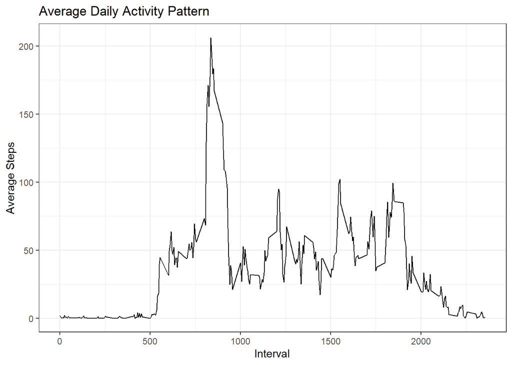

```r
average_int <- group_by(dat, interval) %>% summarize(avg_int = mean(steps, na.rm = T))
{ggplot(average_int, aes(x = interval, y = avg_int)) +
        geom_line() +
        labs(title = "Average Daily Activity Pattern",
             x = "Interval",
             y = "Average Steps") +
        theme_bw()}
```

The 5-min interval with the maximun average is interval 835!

```r
head(arrange(average_int, desc(avg_int)))
```

```
## # A tibble: 6 x 2
##   interval avg_int
##      <int>   <dbl>
## 1      835    206.
## 2      840    196.
## 3      850    183.
## 4      845    180.
## 5      830    177.
## 6      820    171.
```

## Imputing missing values

As shown above, the total number of missing values is 2304. We can double check it by calculating the summary of the steps.

```r
summary(dat$steps)
```

```
##    Min. 1st Qu.  Median    Mean 3rd Qu.    Max.    NA's
##    0.00    0.00    0.00   37.38   12.00  806.00    2304
```

Our strategy to impute the missing values is to use the median value for each interval. To do this, it is requiered to calculate the median steps for each interval.

```r
med_int <- group_by(dat, interval) %>% summarize(median_int = median(steps, na.rm = T))
head(med_int)
```

```
## # A tibble: 6 x 2
##   interval median_int
##      <int>      <int>
## 1        0          0
## 2        5          0
## 3       10          0
## 4       15          0
## 5       20          0
## 6       25          0
```

Now, it is time to impute the missing values and create a new data frame.

```r
new_dat <- data.frame()
for(i in 1:length(dat$interval)){
    if (is.na(dat[i,1])){
        new_dat[i,1] = med_int[match(dat[i,3], med_int$interval),2]
        new_dat[i,2] = dat[i,3]
        new_dat[i,3] = dat[i,2]
    } else {
        new_dat[i,1] = dat[i,1]
        new_dat[i,2] = dat[i,3]
        new_dat[i,3] = dat[i,2]
    }
}
names(new_dat) <- c("steps", "interval", "date")
summary(new_dat$steps)
```

```
##    Min. 1st Qu.  Median    Mean 3rd Qu.    Max.
##       0       0       0      33       8     806
```

To show the impact of imputing data, we can show the same histogram as the one in the begining, but with our new data set.

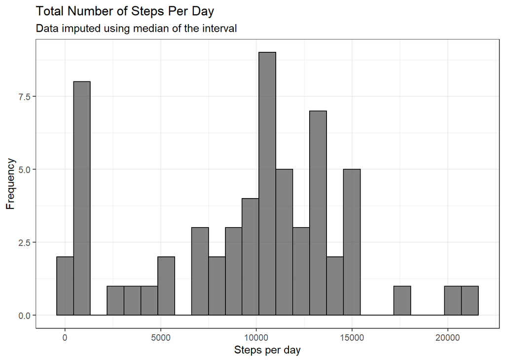

```r
total_day_new <- group_by(new_dat, date) %>% summarize(total_steps = sum(steps))
{ggplot(total_day_new, aes(total_steps)) +
        geom_histogram(bins = 25, alpha = 0.75, color = "black") +
        labs(title = "Total Number of Steps Per Day",
             subtitle = "Data imputed using median of the interval",
             x = "Steps per day",
             y = "Frequency") +
        theme_bw()}
```

Also, we can compare the mean and median values of each data set.

```r
summary(dat$steps)
```

```
##    Min. 1st Qu.  Median    Mean 3rd Qu.    Max.    NA's
##    0.00    0.00    0.00   37.38   12.00  806.00    2304
```

```r
summary(new_dat$steps)
```

```
##    Min. 1st Qu.  Median    Mean 3rd Qu.    Max.
##       0       0       0      33       8     806
```

As show in the above comparisson, after imputing the data, the upper side of the distribution decreasead.

## Are there differences in activity patterns between weekdays and weekends?

To compare this, first, we need a new factor variable indicating if is weekday or not.

```r
new_dat <- mutate(new_dat,
                  Day = weekdays(date, abbreviate = T))
weekends <- c("Sat", "Sun")
for(i in 1:length(new_dat$steps)){
    if (new_dat[i,4] %in% weekends){
        new_dat[i,4] = "weekend"
    } else {
        new_dat[i,4] = "weekday"
    }
}
new_dat <- mutate(new_dat, Day = as.factor(Day))
summary(new_dat$Day)
```

```
## weekday weekend
##   12960    4608
```

Now me can compare the pattern for weekdays and weekends using the average number of steps per interval across all days.

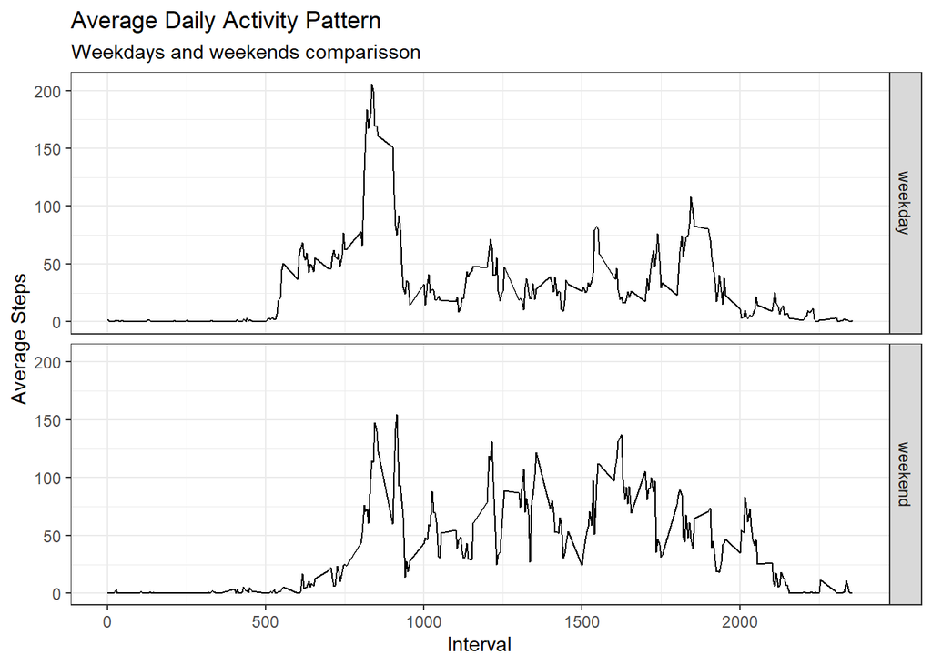

```r
average_comp <- group_by(new_dat, interval, Day) %>% summarize(avg_int = mean(steps))
{ggplot(average_comp, aes(x = interval, y = avg_int)) +
        geom_line() +
        facet_grid(Day~.) +
        labs(title = "Average Daily Activity Pattern",
             subtitle = "Weekdays and weekends comparisson",
             x = "Interval",
             y = "Average Steps") +
        theme_bw()}
```